# final

```python
#importing all the needed libraries
import pandas as pd
import os
import matplotlib.pyplot as plt
import seaborn as sns
```

## Data Understanding

```python
df.dtypes#showing data type of all column
```

```
Order ID            float64
Product              object
Quantity Ordered    float64
Price Each          float64
Order Date           object
Purchase Address     object
dtype: object
```

```python
df.describe()#describe function show all the statistic of numeric data
```

|  | Order ID | Quantity Ordered | Price Each |
| --- | --- | --- | --- |
| count | 185950.000000 | 185950.000000 | 185950.000000 |
| mean | 230417.569379 | 1.124383 | 184.399735 |
| std | 51512.737110 | 0.442793 | 332.731330 |
| min | 141234.000000 | 1.000000 | 2.990000 |
| 25% | 185831.250000 | 1.000000 | 11.950000 |
| 50% | 230367.500000 | 1.000000 | 14.950000 |
| 75% | 275035.750000 | 1.000000 | 150.000000 |
| max | 319670.000000 | 9.000000 | 1700.000000 |

```python
df1=df.groupby('Product').mean()['Price Each']#using mean the price each with its product name is extracted
df2=pd.DataFrame(df1)#array is converted into dataframe
df2
```

| Product | Price Each |
| --- | --- |
| 20in Monitor | 109.99 |
| 27in 4K Gaming Monitor | 389.99 |
| 27in FHD Monitor | 149.99 |
| 34in Ultrawide Monitor | 379.99 |
| AA Batteries (4-pack) | 3.84 |
| AAA Batteries (4-pack) | 2.99 |
| Apple Airpods Headphones | 150.00 |
| Bose SoundSport Headphones | 99.99 |
| Flatscreen TV | 300.00 |
| Google Phone | 600.00 |
| LG Dryer | 600.00 |
| LG Washing Machine | 600.00 |
| Lightning Charging Cable | 14.95 |
| Macbook Pro Laptop | 1700.00 |
| ThinkPad Laptop | 999.99 |
| USB-C Charging Cable | 11.95 |
| Vareebadd Phone | 400.00 |
| Wired Headphones | 11.99 |
| iPhone | 700.00 |

```python
df1=df['Product'].unique()#Using unique function all the name of product are extracted
df2=pd.DataFrame(df1)#array is converted into dataframe
df2.columns =['Products']#column name is give to dataframe
df2
```

|  | Products |
| --- | --- |
| 0 | USB-C Charging Cable |
| 1 | Bose SoundSport Headphones |
| 2 | Google Phone |
| 3 | Wired Headphones |
| 4 | Macbook Pro Laptop |
| 5 | Lightning Charging Cable |
| 6 | 27in 4K Gaming Monitor |
| 7 | AA Batteries (4-pack) |
| 8 | Apple Airpods Headphones |
| 9 | AAA Batteries (4-pack) |
| 10 | iPhone |
| 11 | Flatscreen TV |
| 12 | 27in FHD Monitor |
| 13 | 20in Monitor |
| 14 | LG Dryer |
| 15 | ThinkPad Laptop |
| 16 | Vareebadd Phone |
| 17 | LG Washing Machine |
| 18 | 34in Ultrawide Monitor |

```python
df1=df.groupby('Product').sum()#Using groupby function by product all the other numeric data are sum
df2=df1['Quantity Ordered']#only sum of quantity ordered is extracted by prodct
df3=pd.DataFrame(df2)#array is converted into dataframe
df3
```

| Product | Quantity Ordered |
| --- | --- |
| 20in Monitor | 4129.0 |
| 27in 4K Gaming Monitor | 6244.0 |
| 27in FHD Monitor | 7550.0 |
| 34in Ultrawide Monitor | 6199.0 |
| AA Batteries (4-pack) | 27635.0 |
| AAA Batteries (4-pack) | 31017.0 |
| Apple Airpods Headphones | 15661.0 |
| Bose SoundSport Headphones | 13457.0 |
| Flatscreen TV | 4819.0 |
| Google Phone | 5532.0 |
| LG Dryer | 646.0 |
| LG Washing Machine | 666.0 |
| Lightning Charging Cable | 23217.0 |
| Macbook Pro Laptop | 4728.0 |
| ThinkPad Laptop | 4130.0 |
| USB-C Charging Cable | 23975.0 |
| Vareebadd Phone | 2068.0 |
| Wired Headphones | 20557.0 |
| iPhone | 6849.0 |

```python
df1=df['Purchase Address'].unique()#Using unique function all the unique are extracted
df2=pd.DataFrame(df1)#array is converted into dataframe
df2.columns =['Unique Purchased Address']#column name is give to dataframe
df2
```

|  | Unique Purchased Address |
| --- | --- |
| 0 | 917 1st St, Dallas, TX 75001 |
| 1 | 682 Chestnut St, Boston, MA 02215 |
| 2 | 669 Spruce St, Los Angeles, CA 90001 |
| 3 | 333 8th St, Los Angeles, CA 90001 |
| 4 | 381 Wilson St, San Francisco, CA 94016 |
| ... | ... |
| 140782 | 260 Spruce St, Boston, MA 02215 |
| 140783 | 911 River St, Dallas, TX 75001 |
| 140784 | 981 4th St, New York City, NY 10001 |
| 140785 | 840 Highland St, Los Angeles, CA 90001 |
| 140786 | 220 12th St, San Francisco, CA 94016 |

140787 rows × 1 columns

## Data Preparation

#### Merging all the 12 months data

```python
df=pd.DataFrame()#creating empty dataframe
files = os.listdir("C:/Users/lucky/OneDrive/Desktop/sales")#listdir lists all the file in that directory
for file in files:#for each loop is used to iteration
    #read_csv is used to read excel csv file and is concatenate with file
    df1 = pd.read_csv("C:/Users/lucky/OneDrive/Desktop/sales/"+file)
    """concat is used to merge, empty dataframe is merged with csv file that is store in df1,
    ignore index helps to continue the index"""
    df = pd.concat([df, df1], ignore_index=True)
df.to_csv('final_all_month_CSV.csv', index=False)#the dataframe of all 12 month is converted to csv file
```

```python
df =pd.read_csv('final_all_month_CSV.csv')#dataframe of all 12 months_
df
```

|  | Order ID | Product | Quantity Ordered | Price Each | Order Date | Purchase Address |
| --- | --- | --- | --- | --- | --- | --- |
| 0 | 176558.0 | USB-C Charging Cable | 2.0 | 11.95 | 4/19/2019 8:46 | 917 1st St, Dallas, TX 75001 |
| 1 | NaN | NaN | NaN | NaN | NaN | NaN |
| 2 | 176559.0 | Bose SoundSport Headphones | 1.0 | 99.99 | 4/7/2019 22:30 | 682 Chestnut St, Boston, MA 02215 |
| 3 | 176560.0 | Google Phone | 1.0 | 600.00 | 4/12/2019 14:38 | 669 Spruce St, Los Angeles, CA 90001 |
| 4 | 176560.0 | Wired Headphones | 1.0 | 11.99 | 4/12/2019 14:38 | 669 Spruce St, Los Angeles, CA 90001 |
| ... | ... | ... | ... | ... | ... | ... |
| 186845 | 259353.0 | AAA Batteries (4-pack) | 3.0 | 2.99 | 9/17/2019 20:56 | 840 Highland St, Los Angeles, CA 90001 |
| 186846 | 259354.0 | iPhone | 1.0 | 700.00 | 9/1/2019 16:00 | 216 Dogwood St, San Francisco, CA 94016 |
| 186847 | 259355.0 | iPhone | 1.0 | 700.00 | 9/23/2019 7:39 | 220 12th St, San Francisco, CA 94016 |
| 186848 | 259356.0 | 34in Ultrawide Monitor | 1.0 | 379.99 | 9/19/2019 17:30 | 511 Forest St, San Francisco, CA 94016 |
| 186849 | 259357.0 | USB-C Charging Cable | 1.0 | 11.95 | 9/30/2019 0:18 | 250 Meadow St, San Francisco, CA 94016 |

186850 rows × 6 columns

#### Removing Nan value

```python
df.isna().sum()#isna function helps to find null values in the dataframe using sum function all the null values are counted.
```

```
Order ID            900
Product             900
Quantity Ordered    900
Price Each          900
Order Date          900
Purchase Address    900
dtype: int64
```

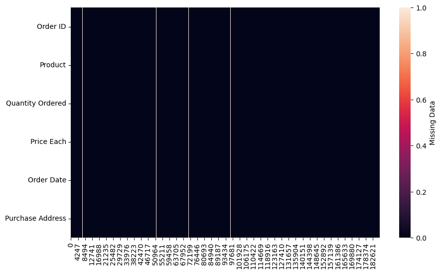

```python
plt.figure(figsize=(10,6))#figure size is set
sns.heatmap(df.isna().transpose(), cbar_kws={'label': 'Missing Data'})#using heat map null values are plotted
```

```python
"""Using dropna all the null values are removed where how helps to remove all null values and inplace true helps to permanent
remove it in this dataframe"""
df.dropna(how = 'all', inplace = True)
```

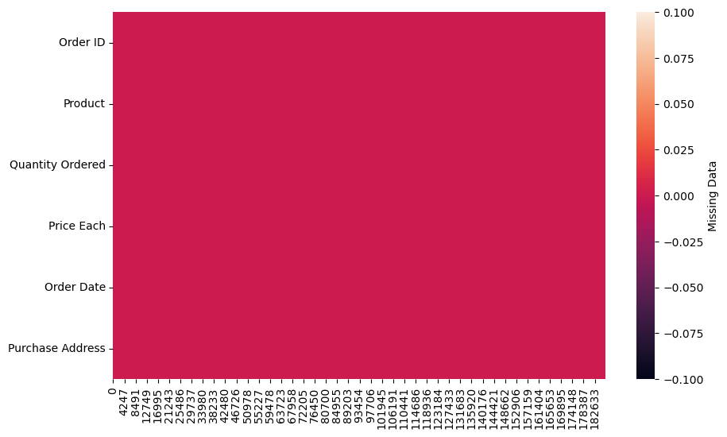

```python
plt.figure(figsize=(10,6))
sns.heatmap(df.isna().transpose(), cbar_kws={'label': 'Missing Data'})#using heat map null values are plotted if there is
```

```python
df.isna().sum()#isna function helps to find null values in the dataframe using sum function all the null values are counted.
```

```
Order ID            0
Product             0
Quantity Ordered    0
Price Each          0
Order Date          0
Purchase Address    0
dtype: int64
```

#### Converting quantity ordered and price each to numeric

```python
#Qunatity ordered and price each columns data is changed to numeric using apply function
df[['Quantity Ordered','Price Each']] = df[['Quantity Ordered','Price Each']].apply(pd.to_numeric)
df
```

|  | Order ID | Product | Quantity Ordered | Price Each | Order Date | Purchase Address |
| --- | --- | --- | --- | --- | --- | --- |
| 0 | 176558.0 | USB-C Charging Cable | 2.0 | 11.95 | 4/19/2019 8:46 | 917 1st St, Dallas, TX 75001 |
| 2 | 176559.0 | Bose SoundSport Headphones | 1.0 | 99.99 | 4/7/2019 22:30 | 682 Chestnut St, Boston, MA 02215 |
| 3 | 176560.0 | Google Phone | 1.0 | 600.00 | 4/12/2019 14:38 | 669 Spruce St, Los Angeles, CA 90001 |
| 4 | 176560.0 | Wired Headphones | 1.0 | 11.99 | 4/12/2019 14:38 | 669 Spruce St, Los Angeles, CA 90001 |
| 5 | 176561.0 | Wired Headphones | 1.0 | 11.99 | 4/30/2019 9:27 | 333 8th St, Los Angeles, CA 90001 |
| ... | ... | ... | ... | ... | ... | ... |
| 186845 | 259353.0 | AAA Batteries (4-pack) | 3.0 | 2.99 | 9/17/2019 20:56 | 840 Highland St, Los Angeles, CA 90001 |
| 186846 | 259354.0 | iPhone | 1.0 | 700.00 | 9/1/2019 16:00 | 216 Dogwood St, San Francisco, CA 94016 |
| 186847 | 259355.0 | iPhone | 1.0 | 700.00 | 9/23/2019 7:39 | 220 12th St, San Francisco, CA 94016 |
| 186848 | 259356.0 | 34in Ultrawide Monitor | 1.0 | 379.99 | 9/19/2019 17:30 | 511 Forest St, San Francisco, CA 94016 |
| 186849 | 259357.0 | USB-C Charging Cable | 1.0 | 11.95 | 9/30/2019 0:18 | 250 Meadow St, San Francisco, CA 94016 |

185950 rows × 6 columns

```python
df.dtypes#dtypes helps to show data type of columns
```

```
Order ID            float64
Product              object
Quantity Ordered    float64
Price Each          float64
Order Date           object
Purchase Address     object
dtype: object
```

#### Adding new column month

```python
df['Order Date']=pd.to_datetime(df['Order Date'])#it converts order date to pandas date and time
df['Month']=df['Order Date'].dt.month.astype(int)#month column is extracted from it and covenverted to int using astype
df
```

|  | Order ID | Product | Quantity Ordered | Price Each | Order Date | Purchase Address | Month |
| --- | --- | --- | --- | --- | --- | --- | --- |
| 0 | 176558.0 | USB-C Charging Cable | 2.0 | 11.95 | 2019-04-19 08:46:00 | 917 1st St, Dallas, TX 75001 | 4 |
| 2 | 176559.0 | Bose SoundSport Headphones | 1.0 | 99.99 | 2019-04-07 22:30:00 | 682 Chestnut St, Boston, MA 02215 | 4 |
| 3 | 176560.0 | Google Phone | 1.0 | 600.00 | 2019-04-12 14:38:00 | 669 Spruce St, Los Angeles, CA 90001 | 4 |
| 4 | 176560.0 | Wired Headphones | 1.0 | 11.99 | 2019-04-12 14:38:00 | 669 Spruce St, Los Angeles, CA 90001 | 4 |
| 5 | 176561.0 | Wired Headphones | 1.0 | 11.99 | 2019-04-30 09:27:00 | 333 8th St, Los Angeles, CA 90001 | 4 |
| ... | ... | ... | ... | ... | ... | ... | ... |
| 186845 | 259353.0 | AAA Batteries (4-pack) | 3.0 | 2.99 | 2019-09-17 20:56:00 | 840 Highland St, Los Angeles, CA 90001 | 9 |
| 186846 | 259354.0 | iPhone | 1.0 | 700.00 | 2019-09-01 16:00:00 | 216 Dogwood St, San Francisco, CA 94016 | 9 |
| 186847 | 259355.0 | iPhone | 1.0 | 700.00 | 2019-09-23 07:39:00 | 220 12th St, San Francisco, CA 94016 | 9 |
| 186848 | 259356.0 | 34in Ultrawide Monitor | 1.0 | 379.99 | 2019-09-19 17:30:00 | 511 Forest St, San Francisco, CA 94016 | 9 |
| 186849 | 259357.0 | USB-C Charging Cable | 1.0 | 11.95 | 2019-09-30 00:18:00 | 250 Meadow St, San Francisco, CA 94016 | 9 |

185950 rows × 7 columns

```python
df.dtypes#dtypes helps to show data type of columns
```

```
Order ID                   float64
Product                     object
Quantity Ordered           float64
Price Each                 float64
Order Date          datetime64[ns]
Purchase Address            object
Month                        int32
dtype: object
```

#### Adding new column city

```python
seperate=df['Purchase Address'].str.split(",")#The purchase address is splited using comma
df["City"] = seperate.str[1]#the first index of the splited string is converted to new column city
df
```

|  | Order ID | Product | Quantity Ordered | Price Each | Order Date | Purchase Address | Month | City |
| --- | --- | --- | --- | --- | --- | --- | --- | --- |
| 0 | 176558.0 | USB-C Charging Cable | 2.0 | 11.95 | 2019-04-19 08:46:00 | 917 1st St, Dallas, TX 75001 | 4 | Dallas |
| 2 | 176559.0 | Bose SoundSport Headphones | 1.0 | 99.99 | 2019-04-07 22:30:00 | 682 Chestnut St, Boston, MA 02215 | 4 | Boston |
| 3 | 176560.0 | Google Phone | 1.0 | 600.00 | 2019-04-12 14:38:00 | 669 Spruce St, Los Angeles, CA 90001 | 4 | Los Angeles |
| 4 | 176560.0 | Wired Headphones | 1.0 | 11.99 | 2019-04-12 14:38:00 | 669 Spruce St, Los Angeles, CA 90001 | 4 | Los Angeles |
| 5 | 176561.0 | Wired Headphones | 1.0 | 11.99 | 2019-04-30 09:27:00 | 333 8th St, Los Angeles, CA 90001 | 4 | Los Angeles |
| ... | ... | ... | ... | ... | ... | ... | ... | ... |
| 186845 | 259353.0 | AAA Batteries (4-pack) | 3.0 | 2.99 | 2019-09-17 20:56:00 | 840 Highland St, Los Angeles, CA 90001 | 9 | Los Angeles |
| 186846 | 259354.0 | iPhone | 1.0 | 700.00 | 2019-09-01 16:00:00 | 216 Dogwood St, San Francisco, CA 94016 | 9 | San Francisco |
| 186847 | 259355.0 | iPhone | 1.0 | 700.00 | 2019-09-23 07:39:00 | 220 12th St, San Francisco, CA 94016 | 9 | San Francisco |
| 186848 | 259356.0 | 34in Ultrawide Monitor | 1.0 | 379.99 | 2019-09-19 17:30:00 | 511 Forest St, San Francisco, CA 94016 | 9 | San Francisco |
| 186849 | 259357.0 | USB-C Charging Cable | 1.0 | 11.95 | 2019-09-30 00:18:00 | 250 Meadow St, San Francisco, CA 94016 | 9 | San Francisco |

185950 rows × 8 columns

## Data Analysis

#### Calculating statistic value

```python
#using sum, mean, standard deviation, skewness and kurtosis inbuilt function values of price each and quantity ordered was calculated
print("Mean of Price Each is",df['Price Each'].mean())
print("Mean sum of Quantity Ordered is",df['Quantity Ordered'].sum())
print("Standard Deviation of Price Each is",df['Price Each'].std())
print("Skewness of Price Each is",df['Price Each'].skew())
print("Kurtosis of Price Each is", df['Price Each'].kurtosis())
```

```
Mean of Price Each is 184.3997347670135
Mean sum of Quantity Ordered is 209079.0
Standard Deviation of Price Each is 332.7313298840936
Skewness of Price Each is 2.8721487292935257
Kurtosis of Price Each is 9.094568341148197
```

#### Correlation Analysis

Correlation refers to the degree of linear relationship between the two variables which is measured by Correlation Coefficient (r), values ranges from +1 to -1 in which +1 denotes strong positive correlation and -1 denotes strong negative correlation.

In above dataframe correlation cofficient is calculated using corr() function which shows that mostly +1 or strong postive correlation is between same datas which doesn't mean anything

Quantity order and Month

```python
df.corr()
```

|  | Order ID | Quantity Ordered | Price Each | Month |
| --- | --- | --- | --- | --- |
| Order ID | 1.000000 | 0.000702 | -0.002857 | 0.993063 |
| Quantity Ordered | 0.000702 | 1.000000 | -0.148272 | 0.000791 |
| Price Each | -0.002857 | -0.148272 | 1.000000 | -0.003375 |
| Month | 0.993063 | 0.000791 | -0.003375 | 1.000000 |

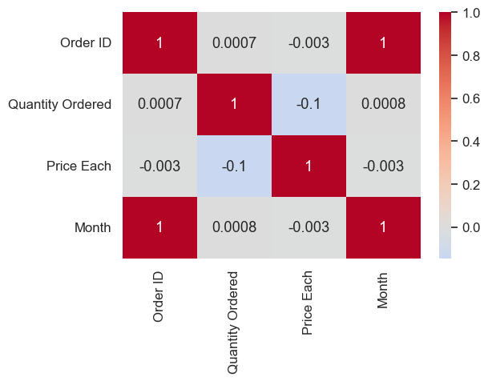

```python
corrs=df.corr()#using corr() function correlation cofficient of each column is extracted
plt.figure(figsize=(6, 4), facecolor='w', edgecolor='k')#color and size of graph is set
sns.set(font_scale=1.1)#font size of the columns are given
sns.heatmap(corrs, cmap='coolwarm', center = 0,  annot=True, fmt='.1g')#heatmap is plotted using seaborn library
```

## Data Exploration

#### Adding new column total price

```python
#total price column is created by multiplying quantity ordered and price each
df['Total Price']=df['Quantity Ordered']*df['Price Each']
df.head()
```

|  | Order ID | Product | Quantity Ordered | Price Each | Order Date | Purchase Address | Month | City | Total Price |
| --- | --- | --- | --- | --- | --- | --- | --- | --- | --- |
| 0 | 176558.0 | USB-C Charging Cable | 2.0 | 11.95 | 2019-04-19 08:46:00 | 917 1st St, Dallas, TX 75001 | 4 | Dallas | 23.90 |
| 2 | 176559.0 | Bose SoundSport Headphones | 1.0 | 99.99 | 2019-04-07 22:30:00 | 682 Chestnut St, Boston, MA 02215 | 4 | Boston | 99.99 |
| 3 | 176560.0 | Google Phone | 1.0 | 600.00 | 2019-04-12 14:38:00 | 669 Spruce St, Los Angeles, CA 90001 | 4 | Los Angeles | 600.00 |
| 4 | 176560.0 | Wired Headphones | 1.0 | 11.99 | 2019-04-12 14:38:00 | 669 Spruce St, Los Angeles, CA 90001 | 4 | Los Angeles | 11.99 |
| 5 | 176561.0 | Wired Headphones | 1.0 | 11.99 | 2019-04-30 09:27:00 | 333 8th St, Los Angeles, CA 90001 | 4 | Los Angeles | 11.99 |

#### Showing highest months sales

```python
df.groupby('Month').sum()#Using groupby function, by month all the other numeric data are sum
```

| Month | Order ID | Quantity Ordered | Price Each | Total Price |
| --- | --- | --- | --- | --- |
| 1 | 1.421631e+09 | 10903.0 | 1811768.38 | 1822256.73 |
| 2 | 1.871053e+09 | 13449.0 | 2188884.72 | 2202022.42 |
| 3 | 2.564811e+09 | 17005.0 | 2791207.83 | 2807100.38 |
| 4 | 3.387347e+09 | 20558.0 | 3367671.02 | 3390670.24 |
| 5 | 3.345872e+09 | 18667.0 | 3135125.13 | 3152606.75 |
| 6 | 2.932976e+09 | 15253.0 | 2562025.61 | 2577802.26 |
| 7 | 3.284140e+09 | 16072.0 | 2632539.56 | 2647775.76 |
| 8 | 2.899374e+09 | 13448.0 | 2230345.42 | 2244467.88 |
| 9 | 2.948727e+09 | 13109.0 | 2084992.09 | 2097560.13 |
| 10 | 5.457110e+09 | 22703.0 | 3715554.83 | 3736726.88 |
| 11 | 5.047203e+09 | 19798.0 | 3180600.68 | 3199603.20 |
| 12 | 7.685905e+09 | 28114.0 | 4588415.41 | 4613443.34 |

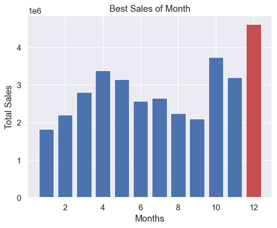

```python
sumall=df.groupby('Month')#Using groupby function, month are extracted
price=sumall.sum()['Total Price']#Using groupby function, by month sum of only total price column is extracted
months=[month for month , df in sumall]#for loop is used access same month by the total price
colors=['b','b','b','b','b','b','b','b','b','b','b','r']#color for each bar is given
#Using groupby function, by month all the other numeric data are sum and only total price column is selected
plt.bar(months, price, color=colors)#using matplotlib the bar graph is plotted
plt.xlabel('Months')#x-axis label is given
plt.ylabel('Total Sales')#y-axis label is given
plt.title("Best Sales of Month")
plt.show()
```

#### Showing most ordered product by city

```python
df.groupby('City').sum()#Using groupby function, by city all the other numeric data are sum
```

| City | Order ID | Quantity Ordered | Price Each | Month | Total Price |
| --- | --- | --- | --- | --- | --- |
| Atlanta | 3.423838e+09 | 16602.0 | 2779908.20 | 104794 | 2795498.58 |
| Austin | 2.280982e+09 | 11153.0 | 1809873.61 | 69829 | 1819581.75 |
| Boston | 4.598265e+09 | 22528.0 | 3637409.77 | 141112 | 3661642.01 |
| Dallas | 3.415644e+09 | 16730.0 | 2752627.82 | 104620 | 2767975.40 |
| Los Angeles | 6.811085e+09 | 33289.0 | 5421435.23 | 208325 | 5452570.80 |
| New York City | 5.736334e+09 | 27932.0 | 4635370.83 | 175741 | 4664317.43 |
| Portland | 2.868861e+09 | 14053.0 | 2307747.47 | 87765 | 2320490.61 |
| San Francisco | 1.030444e+10 | 50239.0 | 8211461.74 | 315520 | 8262203.91 |
| Seattle | 3.406694e+09 | 16553.0 | 2733296.01 | 104941 | 2747755.48 |

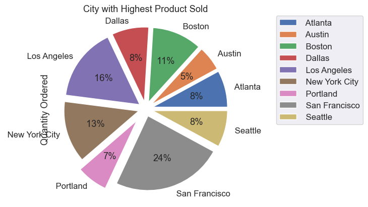

```python
#Using groupby function, by city total price is shown using pie chart, explode helps to give space between each
df.groupby(['City']).sum().plot(kind='pie', y='Quantity Ordered', explode=(0.1, 0.1, 0.1,0.1,0.1,0.1,0.2,0.1,0.1), autopct='%1.0f%%')
plt.legend(bbox_to_anchor=(1.2, 1), loc='upper left', borderaxespad=0)
plt.title("City with Highest Product Sold")
```

#### Showing most ordered product by product

```python
df.groupby('Product').sum()#Using groupby function, by product all the other numeric data are sum
```

| Product | Order ID | Quantity Ordered | Price Each | Month | Total Price |
| --- | --- | --- | --- | --- | --- |
| 20in Monitor | 9.508897e+08 | 4129.0 | 451068.99 | 29336 | 454148.71 |
| 27in 4K Gaming Monitor | 1.442589e+09 | 6244.0 | 2429637.70 | 44440 | 2435097.56 |
| 27in FHD Monitor | 1.724224e+09 | 7550.0 | 1125974.93 | 52558 | 1132424.50 |
| 34in Ultrawide Monitor | 1.418986e+09 | 6199.0 | 2348718.19 | 43304 | 2355558.01 |
| AA Batteries (4-pack) | 4.744174e+09 | 27635.0 | 79015.68 | 145558 | 106118.40 |
| AAA Batteries (4-pack) | 4.764959e+09 | 31017.0 | 61716.59 | 146370 | 92740.83 |
| Apple Airpods Headphones | 3.579120e+09 | 15661.0 | 2332350.00 | 109477 | 2349150.00 |
| Bose SoundSport Headphones | 3.071496e+09 | 13457.0 | 1332366.75 | 94113 | 1345565.43 |
| Flatscreen TV | 1.110943e+09 | 4819.0 | 1440000.00 | 34224 | 1445700.00 |
| Google Phone | 1.262237e+09 | 5532.0 | 3315000.00 | 38305 | 3319200.00 |
| LG Dryer | 1.465563e+08 | 646.0 | 387600.00 | 4383 | 387600.00 |
| LG Washing Machine | 1.507187e+08 | 666.0 | 399600.00 | 4523 | 399600.00 |
| Lightning Charging Cable | 4.994091e+09 | 23217.0 | 323787.10 | 153092 | 347094.15 |
| Macbook Pro Laptop | 1.091958e+09 | 4728.0 | 8030800.00 | 33548 | 8037600.00 |
| ThinkPad Laptop | 9.487932e+08 | 4130.0 | 4127958.72 | 28950 | 4129958.70 |
| USB-C Charging Cable | 5.049538e+09 | 23975.0 | 261740.85 | 154819 | 286501.25 |
| Vareebadd Phone | 4.725325e+08 | 2068.0 | 826000.00 | 14309 | 827200.00 |
| Wired Headphones | 4.350952e+09 | 20557.0 | 226395.18 | 133397 | 246478.43 |
| iPhone | 1.571390e+09 | 6849.0 | 4789400.00 | 47941 | 4794300.00 |

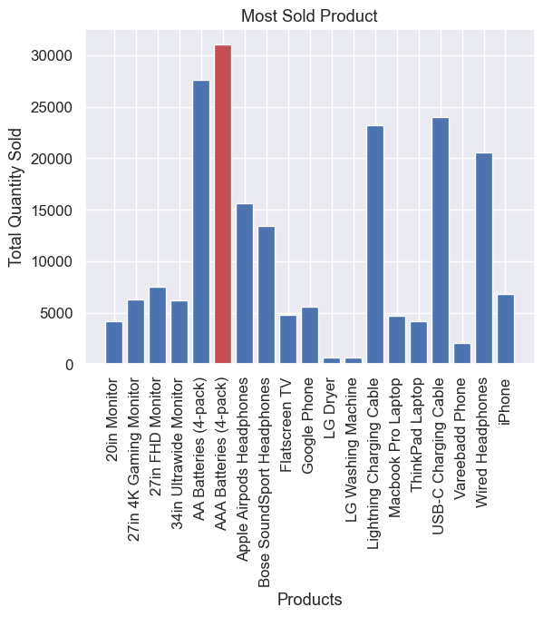

```python
sumall=df.groupby('Product')#Using groupby function, month are extracted
quantity=sumall.sum()['Quantity Ordered']#Using groupby function, by month sum of only total price column is extracted
products=[product for product , df in sumall]#for loop is used access same month by the total price
colors=['b','b','b','b','b','r','b','b','b','b','b','b','b','b','b']#color for each bar is given
#Using groupby function, by month all the other numeric data are sum and only total price column is selected
plt.bar(products, quantity, color=colors)#using matplotlib the bar graph is plotted
plt.xlabel('Products')#x-axis label is given
plt.ylabel('Total Quantity Sold')#y-axis label is given
plt.title("Most Sold Product")
plt.xticks(rotation=90)
plt.show()
```

#### Creating new column hours and histogram of data by hours

```python
df['Hours']=df['Order Date'].dt.hour#hours column is extracted the dataframe
df.head()
```

|  | Order ID | Product | Quantity Ordered | Price Each | Order Date | Purchase Address | Month | City | Total Price | Hours |
| --- | --- | --- | --- | --- | --- | --- | --- | --- | --- | --- |
| 0 | 176558.0 | USB-C Charging Cable | 2.0 | 11.95 | 2019-04-19 08:46:00 | 917 1st St, Dallas, TX 75001 | 4 | Dallas | 23.90 | 8 |
| 2 | 176559.0 | Bose SoundSport Headphones | 1.0 | 99.99 | 2019-04-07 22:30:00 | 682 Chestnut St, Boston, MA 02215 | 4 | Boston | 99.99 | 22 |
| 3 | 176560.0 | Google Phone | 1.0 | 600.00 | 2019-04-12 14:38:00 | 669 Spruce St, Los Angeles, CA 90001 | 4 | Los Angeles | 600.00 | 14 |
| 4 | 176560.0 | Wired Headphones | 1.0 | 11.99 | 2019-04-12 14:38:00 | 669 Spruce St, Los Angeles, CA 90001 | 4 | Los Angeles | 11.99 | 14 |
| 5 | 176561.0 | Wired Headphones | 1.0 | 11.99 | 2019-04-30 09:27:00 | 333 8th St, Los Angeles, CA 90001 | 4 | Los Angeles | 11.99 | 9 |

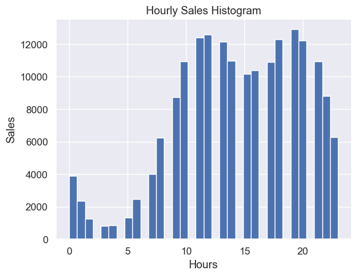

```python
df1=df['Hours']#column hours from dataframe is stored in a variable
plt.hist([df1], bins=34)#histogram was plotted on basic of hour whereas bins helps to set distance between lines
plt.title("Hourly Sales Histogram")#tite of histogram is given
plt.xlabel("Hours")#label of x axis is given
plt.ylabel("Sales")#label of y axis is given
plt.show()
```

# Findings

According to the data, this data is of a electronic store which sells various products including phones, TV's, laptop, monitors, batteries, headphone, dryer and charging cables. This store is located in USA and is sold in 9 cities of USA.

The store sells this year is of total 34492035.97 dollars

In the city of San Francisco total quantity ordered highest of 50239 with highest total sales of 8262203.91 dollars

Highest quantity ordered product is AAA Batteries (4-pack) of 31017 and LG Dryer is least quantity order though the the total sales of LG Dryer is way more than AAA Batteries due to difference in price.

In 3AM in the morning least quantity of product are ordered which is 831 whereas in 7PM in the evening most quantity of product are ordered which is 12905

168552 people have order only one product at a time and only 3 times people have order most product which is 9

## Extra Graph

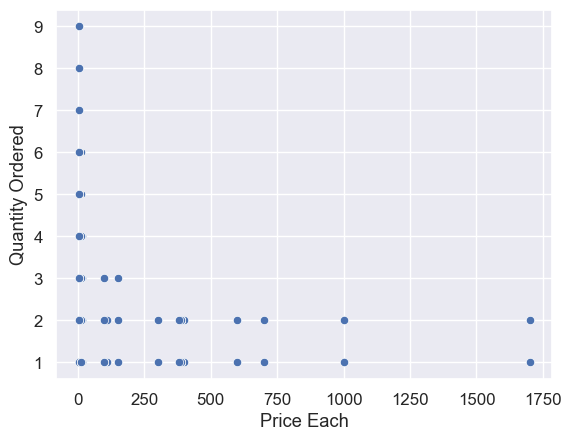

```python
sns.scatterplot(x="Price Each", y="Quantity Ordered", data=df)#scatter plot helps to show correlation between data
```

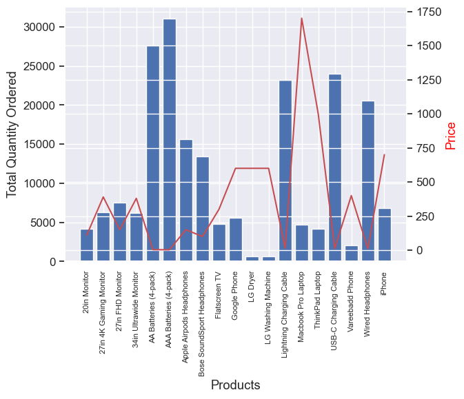

```python
sump=df.groupby('Product')#Using groupby function, product is extracted
price=df.groupby('Product').mean()['Price Each']#Using groupby function, by product sum of only total price column is extracted
fig, axis1=plt.subplots()
axis2=axis1.twinx()
quantity=sump.sum()['Quantity Ordered']
products=[product for product , df in sump]#for loop is used access same product by the total price
axis1.bar(products, quantity)#using product name and quantity order bar graph is plotted
axis2.plot(products, price, 'r-')#using product and its price a line graph is plotted
#using label, labels are given to following axis
axis1.set_xlabel('Products')
axis1.set_ylabel('Total Quantity Ordered')
axis2.set_ylabel('Price', color='red')
#xticklabels helps to increase height of the graph
axis1.set_xticklabels(products, rotation='vertical', size=8,)
plt.show()
```

[figure not shown]

```python
df1=df['City']#column city from dataframe is stored in a variable
colors = ['green']
plt.hist([df1], bins=15, color = colors)#histogram was plotted on basic of city whereas bins helps to set distance between lines
plt.title("Quantity Ordered by City Histogram")#tite of histogram is given
plt.xticks(rotation=90)#helps to increase height of the graph
plt.xlabel("City")#label of x axis is given
plt.ylabel("Quantity Ordered")#label of y axis is given
plt.show()
```

```python
df.groupby(['Quantity Ordered']).count()
```

| Quantity Ordered | Order ID | Product | Price Each | Order Date | Purchase Address | Month | City | Total Price | Hours |
| --- | --- | --- | --- | --- | --- | --- | --- | --- | --- |
| 1.0 | 168552 | 168552 | 168552 | 168552 | 168552 | 168552 | 168552 | 168552 | 168552 |
| 2.0 | 13324 | 13324 | 13324 | 13324 | 13324 | 13324 | 13324 | 13324 | 13324 |
| 3.0 | 2920 | 2920 | 2920 | 2920 | 2920 | 2920 | 2920 | 2920 | 2920 |
| 4.0 | 806 | 806 | 806 | 806 | 806 | 806 | 806 | 806 | 806 |
| 5.0 | 236 | 236 | 236 | 236 | 236 | 236 | 236 | 236 | 236 |
| 6.0 | 80 | 80 | 80 | 80 | 80 | 80 | 80 | 80 | 80 |
| 7.0 | 24 | 24 | 24 | 24 | 24 | 24 | 24 | 24 | 24 |
| 8.0 | 5 | 5 | 5 | 5 | 5 | 5 | 5 | 5 | 5 |
| 9.0 | 3 | 3 | 3 | 3 | 3 | 3 | 3 | 3 | 3 |

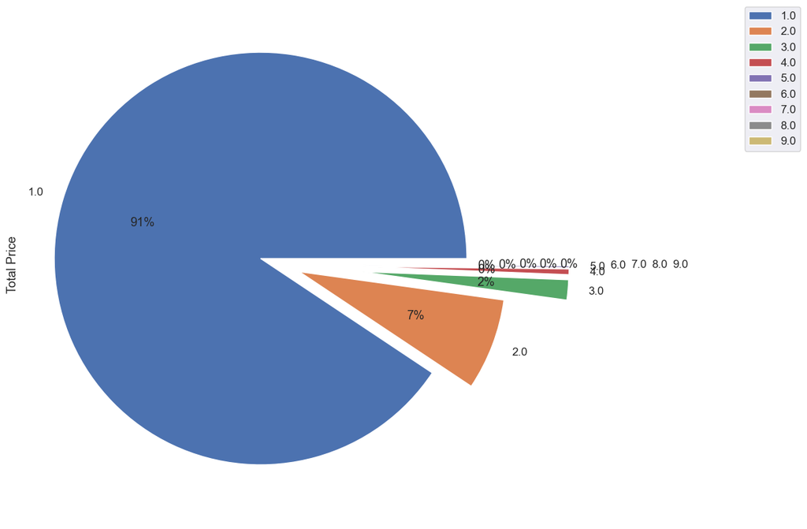

```python
df.groupby(['Quantity Ordered']).count().plot(kind='pie', y='Total Price', explode=(0.1, 0.1, 0.4,0.4,0.4,0.5,0.6,0.7,0.8), autopct='%1.0f%%', figsize=(20, 10))
plt.legend(bbox_to_anchor=(1.4, 1), loc='upper left', borderaxespad=0)
```